# The Isoformic method applied to long reads datasets

Carlos Augusto da Mata-Machado

Laboratory of Genetics Biochemistry, Universidade Federal de Minas Gerais, Belo Horizonte, Brazil

Izabela Mamede Conceição

Laboratory of Genetics Biochemistry, Universidade Federal de Minas Gerais, Belo Horizonte, Brazil

Lucio Rezende Queiroz

Department of Pathology and Laboratory Medicine, Weill Cornell Medicine, New York, USA

2025-08-17

## Information

Although Isoformic was mainly developed as a package to visualize and interpret isoform-level data from short reads, it works just as well for differential expression performed with long reads. To achieve Isoformic’s inputs, we recommend the use of [`oarfish`](https://github.com/COMBINE-lab/oarfish/) for transcript-level abundance estimation for long reads data (Jousheghani et al., 2025), using the [GENCODE](https://www.gencodegenes.org) annotation of isoforms as reference. In this vignette we use as example a dataset comparing prostate cancer cells treated with lorecivivint (LOR) to DMSO controls, originated from the paper “*Targeting the CLK2/SRSF9 splicing axis in prostate cancer leads to decreased ARV7 expression*” (GEO: GSE259334). All of the demonstrations replicated here for long reads are thoroughly showcased and explained in the [introduction vignette](https://luciorq.github.io/isoformic/articles/isoformic_intro.html), albeit applied to short reads data.

In advanced prostate cancer (PC), resistance to androgen receptor signaling inhibitors (ARSI) is frequently driven by the androgen receptor splice variant ARV7. Its expression is promoted by the CLK2/SRSF9 splicing axis, and inhibition of CLK kinases with small molecules such as lorecivivint (LOR) suppresses ARV7 levels and reduces tumor cell proliferation. To characterize the broader transcriptional effects of this pathway inhibition, we performed the differential expression analysis comparing prostate cancer cells treated with 50 nM LOR to DMSO vehicle controls (Van Goubergen et al., 2024).

## Setting up inputs

Load dependency packages:

```r
library(isoformic)
library(tidyverse)
library(fs)
library(readr)
library(dplyr)
library(tidyr)
library(stringr)
```

We need to properly input some tables to use Isoformic’s functions. These are:

### DET table

The differentially expressed transcripts (DET) table will be our main table. It must include: (1) Ensembl Transcript ID per line, (2) a column labeled `log2FC`, and (3) a column labeled `pvalue` with the corresponding p-values. Additional columns may be present in the table but will not be used in the core analysis. Ensure that the log2(FoldChange) column is called “`log2FC`”. Also ensure the table is the complete, *unfiltered* output (i.e. no `log2FC` or `pvalue` cutoff beforehand)! Example:

```r
DET_table <- read_csv("rds/DET_table.csv") # TODO: add path_package() instead of local read_csv? (.csv's are in /data/mendel/carlosaugustodmm/isoformic_longreads/rds/)
head(DET_table)
```

```
## # A tibble: 6 × 6
##   transcript_id     baseMean    log2FC  lfcSE pvalue qvalue
##   <chr>                <dbl>     <dbl>  <dbl>  <dbl>  <dbl>
## 1 ENST00000832826.1    0.166 -0.000563 0.0655  0.810     NA
## 2 ENST00000832829.1    0.349 -0.000694 0.0655  0.633     NA
## 3 ENST00000831201.1    0.175 -0.000569 0.0655  0.810     NA
## 4 ENST00000831165.1    1.32   0.00146  0.0655  0.460     NA
## 5 ENST00000831154.1    2.48   0.000438 0.0654  0.892     NA
## 6 ENST00000831146.1    1.48   0.000306 0.0655  0.880     NA
```

Then, we merge it with `txtogene_hv48`, a dictionary built using Isoformic’s function `make_tx_to_gene()` on GENCODE human reference transcriptome (in this example, v48), to map transcript IDs to names.

```r
txtogene_hv48 <- isoformic::make_tx_to_gene("ref/gencode.v48.transcripts.fa.gz",
                                            file_type = "fasta"
                                            )

txtogene_hv48 <- txtogene_hv48 |>
  dplyr::select(
    transcript_id, gene_id,
    transcript_name, gene_name,
    transcript_type
    )

head(txtogene_hv48)
```

```
## # A tibble: 6 × 5
##   transcript_id     gene_id           transcript_name gene_name transcript_type
##   <chr>             <chr>             <chr>           <chr>     <chr>
## 1 ENST00000832824.1 ENSG00000290825.2 DDX11L16-260    DDX11L16  lncRNA
## 2 ENST00000832825.1 ENSG00000290825.2 DDX11L16-261    DDX11L16  lncRNA
## 3 ENST00000832826.1 ENSG00000290825.2 DDX11L16-262    DDX11L16  lncRNA
## 4 ENST00000832827.1 ENSG00000290825.2 DDX11L16-263    DDX11L16  lncRNA
## 5 ENST00000832828.1 ENSG00000290825.2 DDX11L16-264    DDX11L16  lncRNA
## 6 ENST00000832829.1 ENSG00000290825.2 DDX11L16-265    DDX11L16  lncRNA
```

```r
DET_table <- DET_table |>
  dplyr::left_join(txtogene_hv48 |> dplyr::select(transcript_id, transcript_name, transcript_type),
                   by = "transcript_id"
                   )
```

### DEG table

We then import the differentially expressed genes (DEG) table and also merge it with `txtogene_hv48`.

```r
DEG_table <- read_csv("rds/DEG_table.csv") # TODO: add path_package() instead of local read_csv?

DEG_table <- DEG_table |>
  dplyr::left_join(unique(txtogene_hv48 |> dplyr::select(gene_id, gene_name)),
                   by = "gene_id"
                   )

head(DEG_table)
```

```
## # A tibble: 6 × 7
##   gene_id            baseMean    log2FC  lfcSE pvalue qvalue gene_name
##   <chr>                 <dbl>     <dbl>  <dbl>  <dbl>  <dbl> <chr>
## 1 ENSG00000000003.16   61.4   -0.00296  0.0568 0.780   1.000 TSPAN6
## 2 ENSG00000000419.14 1460.     0.0144   0.0556 0.491   1.000 DPM1
## 3 ENSG00000000457.14  105.    -0.00324  0.0563 0.801   1.000 SCYL3
## 4 ENSG00000000460.17  218.    -0.0323   0.0683 0.0667  1.000 FIRRM
## 5 ENSG00000000938.13    0.167 -0.000438 0.0578 0.810  NA     FGR
## 6 ENSG00000000971.17    4.89  -0.000854 0.0577 0.788  NA     CFH
```

### TPM table

At last, we read in a data frame containing the TPM for each transcript.

```r
TPM_table <- read_csv("rds/TPM_table.csv")  # TODO: add path_package() instead of local read_csv?

TPM_table <- TPM_table |>
  dplyr::left_join(unique(txtogene_hv48 |> dplyr::select(transcript_id, transcript_name)),
                   by = "transcript_id"
                   )
```

## Further wrangling

### Final DETs table

The DET table needs further wrangling: we will make a cutoff to define the differentially expressed genes, then add a column to the DET table to identify if the parent gene of each transcript passes this cutoff value, using the function `is_deg_sig()`.

```r
DEG_table_new_names_sig <- DEG_table |>
  filter(abs(log2FC) >= 1) |>
  filter(pvalue <= 0.05) |>
  dplyr::select(gene_name) |>
  drop_na()

DEGs_sig_joined <- DEG_table_new_names_sig |>
  left_join(txtogene_hv48, by = "gene_name")
transcript_gene_join <- txtogene_hv48 |>
  dplyr::select(transcript_name, gene_name) |>
  distinct()

DET_table_final <- isoformic::is_deg_sig(DEGs_sig_joined$transcript_name, DET_table)
DET_table_final <- DET_table_final |>
  left_join(transcript_gene_join, by = "transcript_name")
```

### DETs_not_DEGs

Another very informative table we can make, through a simple filter, is `DETs_not_DEGs`, which contain the transcripts that are differentially expressed, while their parent genes are not. This table contains, therefore, cases of isoform switches - i.e. when two transcripts of the same gene are regulated in opposite directions, resulting in no significant overall change in the gene’s total expression.

```r
DETs_not_DEGs <- DET_table_final |>
  filter(pvalue < 0.05,
         abs(log2FC) > 1,
         DEG_sig == "NO"
         )
```

## Colors

Before we create the plots, we’ll define the color scheme for each transcript type, to be used throughout this vignette.

```r
fixed_tx_biotypes <- c(
  "gene", "protein_coding", "retained_intron","protein_coding_CDS_not_defined",
  "nonsense_mediated_decay","lncRNA", "processed_pseudogene", "transcribed_unprocessed_pseudogene",
  "unprocessed_pseudogene", "non_stop_decay", "transcribed_unitary_pseudogene", "pseudogene",
  "unitary_pseudogene"
  )

tx_type_color_names <- c(
  "#fb8072", "#a6d854", "#8da0cb", "#fc8d62",
  "#66c2a5", "#e78ac3", "#ffd92f", "#e5c494",
  "#d9d9d9", "#d9d9d9", "#d9d9d9", "#ffffb3",
  "#d9d9d9"
  )

names(tx_type_color_names) <- fixed_tx_biotypes

tx_type_color_names
```

```
##                               gene                     protein_coding
##                          "#fb8072"                          "#a6d854"
##                    retained_intron     protein_coding_CDS_not_defined
##                          "#8da0cb"                          "#fc8d62"
##            nonsense_mediated_decay                             lncRNA
##                          "#66c2a5"                          "#e78ac3"
##               processed_pseudogene transcribed_unprocessed_pseudogene
##                          "#ffd92f"                          "#e5c494"
##             unprocessed_pseudogene                     non_stop_decay
##                          "#d9d9d9"                          "#d9d9d9"
##     transcribed_unitary_pseudogene                         pseudogene
##                          "#d9d9d9"                          "#ffffb3"
##                 unitary_pseudogene
##                          "#d9d9d9"
```

## Plotting

### Log2FC Plot

This simple plot shows the log2FC values of a gene and its transcripts when comparing case versus control. To generate it, we first build a unified table that merges gene-level and transcript-level differential expression results using the Isoformic function `join_DEG_DET()`.

```r
DEG_DET_table <- isoformic::join_DEG_DET(DEG_table, DET_table_final,
                                         logfc_cut = 1,
                                         pval_cut = 0.05
                                         )
head(DEG_DET_table)
```

```
## # A tibble: 6 × 11
##   id      baseMean   log2FC  lfcSE pvalue qvalue name  transcript_type gene_name
##   <chr>      <dbl>    <dbl>  <dbl>  <dbl>  <dbl> <chr> <chr>           <chr>
## 1 ENSG00…   61.4   -2.96e-3 0.0568 0.780   1.000 TSPA… gene            TSPAN6
## 2 ENSG00… 1460.     1.44e-2 0.0556 0.491   1.000 DPM1  gene            DPM1
## 3 ENSG00…  105.    -3.24e-3 0.0563 0.801   1.000 SCYL3 gene            SCYL3
## 4 ENSG00…  218.    -3.23e-2 0.0683 0.0667  1.000 FIRRM gene            FIRRM
## 5 ENSG00…    0.167 -4.38e-4 0.0578 0.810  NA     FGR   gene            FGR
## 6 ENSG00…    4.89  -8.54e-4 0.0577 0.788  NA     CFH   gene            CFH
## # ℹ 2 more variables: abs_log2FC <dbl>, significance <chr>
```

We can then use `plot_Log2FC()` qwith any gene (or small vector of `gene_name`s) to visualize.

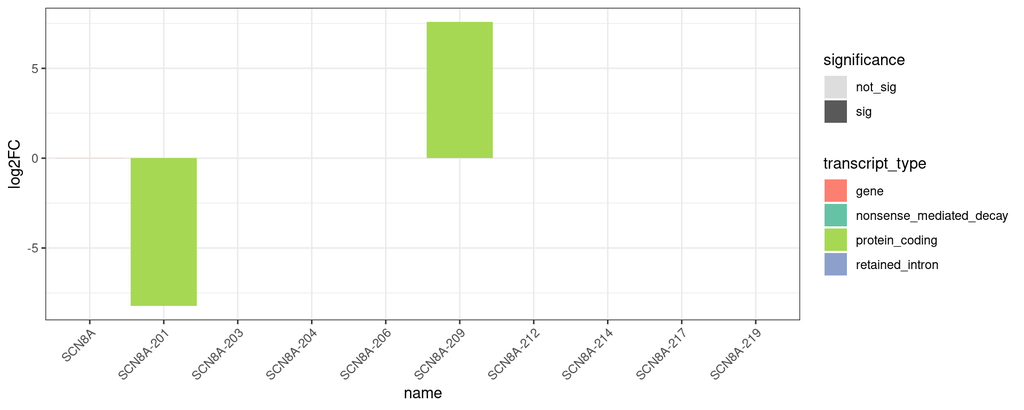

```r
plot_obj <- isoformic::plot_log2FC(DEG_DET_table,
                                   "SCN8A"
                                   )

plot_obj + ggplot2::theme(
  axis.text.x = element_text(angle = 45,  hjust = 1)
  )
```

### Profile Plot

We can also visualize this isoform switch using the Transcripts per Million (TPM) counts instead of fold change, plotting each transcript’s TPM between the conditions. We need to provide, among many inputs, the sample sheet that identify each sample’s condition (and each sample being a column in the TPM table). First, the `prepare_profile_data()` function is used to create the data frame `profile_data_df`.

```r
samplesheet <- read_delim(file = "/data/mendel/carlosaugustodmm/isoformic_longreads/rds/longreads_samplesheet.csv",
                          delim  = ";",
                          col_names = TRUE) # TODO: add path_package() instead of local read_csv?
samplesheet$condition <- as.factor(samplesheet$condition)
samplesheet <- samplesheet |>
  dplyr::select(names, condition)

profile_data_df <- isoformic::prepare_profile_data(
  txi_transcript = TPM_table,
  tx_to_gene = txtogene_hv48,
  sample_metadata = samplesheet,
  de_result_gene = DEG_table,
  de_result_transcript = DET_table_final,
  var = "condition",
  var_levels = c("DMSO_vehicle", "lorecivivint_50nM")
)

head(profile_data_df)
```

```
## # A tibble: 6 × 7
##   genename  condition         mean_TPM      SD transcript_type DE    parent_gene
##   <chr>     <fct>                <dbl>   <dbl> <chr>           <fct> <chr>
## 1 5S_rRNA   DMSO_vehicle         0.223   0.442 gene            No    genename
## 2 5S_rRNA   lorecivivint_50nM    0.222   0.667 gene            No    genename
## 3 5_8S_rRNA DMSO_vehicle         0.679   2.33  gene            No    genename
## 4 5_8S_rRNA lorecivivint_50nM    0.888   1.83  gene            No    genename
## 5 7SK       DMSO_vehicle        52.8   112.    gene            No    genename
## 6 7SK       lorecivivint_50nM   42.3    89.0   gene            No    genename
```

Subsequently, to create the plot, we use the function `plot_tx_expr()` with the gene of interest.

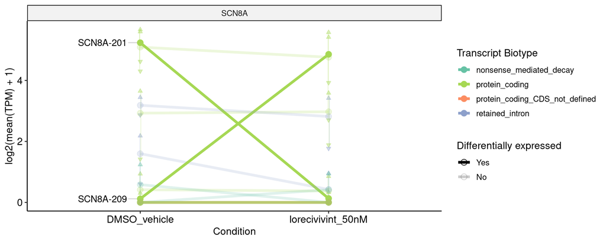

```r
profile_plot <- isoformic::plot_tx_expr(
  genes_to_plot = "SCN8A",
  profile_data = profile_data_df
)

profile_plot
```

### Functional Transcript Enrichment

Performing functional enrichment for isoform-level data is one of the biggest caveats, as there is no annotation for gene sets in transcript-level. To bypass this, our strategy is expanding a known `.gmt` for transcript information and enrich each transcript type separately. We chose the C2 (curated gene sets) gene set from [MSigDB](https://www.gsea-msigdb.org/gsea/msigdb/collections.jsp) and loaded it using `fgsea::gmtPathways()`.

```r
genesets_list <- fgsea::gmtPathways(
  gmt.file = "ref/c2.all.v2024.1.Hs.symbols.gmt"
)

head(str(genesets_list[1:5]))
```

```
## List of 5
##  $ ABBUD_LIF_SIGNALING_1_DN  : chr [1:28] "AHNAK" "ALCAM" "ANKRD40" "ARID1A" ...
##  $ ABBUD_LIF_SIGNALING_1_UP  : chr [1:43] "ACAA2" "ALDOC" "ANXA8L1" "BCL3" ...
##  $ ABBUD_LIF_SIGNALING_2_DN  : chr [1:7] "CGA" "CITED2" "NALCN" "PITX2" ...
##  $ ABBUD_LIF_SIGNALING_2_UP  : chr [1:13] "ATP1B1" "COL11A1" "DAB2" "DCN" ...
##  $ ABDELMOHSEN_ELAVL4_TARGETS: chr [1:16] "BCL2" "CAB39" "CASP3" "CDC42" ...
```

The final DET table can then be enriched using `genesets_list` through the function `run_enrichment()`, which also uses the previously created `txtogene_hv48`. The function expands the gene sets and performs GSEA enrichment. We also have a flag for an arbitrary p-value cutoff (a threshold applied to the *resulting* enrichment table).

```r
enrichment_df <- isoformic::run_enrichment(
  det_df = DET_table_final,
  genesets_list = genesets_list,
  tx_to_gene = txtogene_hv48,
  pval_cutoff = 0.05
)

head(enrichment_df)
```

```
##                                            pathway        pval      padj
##                                             <char>       <num>     <num>
## 1:                        ABBUD_LIF_SIGNALING_2_DN 0.024573949 0.5497123
## 2:            ACEVEDO_LIVER_CANCER_WITH_H3K9ME3_DN 0.003986005 0.2672103
## 3: ACOSTA_PROLIFERATION_INDEPENDENT_MYC_TARGETS_DN 0.036762616 0.5497123
## 4:             ALCALAY_AML_BY_NPM1_LOCALIZATION_DN 0.045625687 0.5497123
## 5:                            ALONSO_METASTASIS_DN 0.029952142 0.5497123
## 6:                        ALONSO_METASTASIS_EMT_DN 0.005190826 0.3049529
##      log2err         ES       NES  size
##        <num>      <num>     <num> <int>
## 1: 0.3524879  0.9726256  1.802166    26
## 2: 0.4070179  0.9113701  1.611198   331
## 3: 0.3217759  0.8594803  1.539901   417
## 4: 0.3217759 -0.7529126 -1.544649   593
## 5: 0.3524879  0.9577879  1.673339    75
```

[output cut: 17 more lines]

We can plot the resulting enrichment for the productive transcripts, in the form of a lollipop plot:

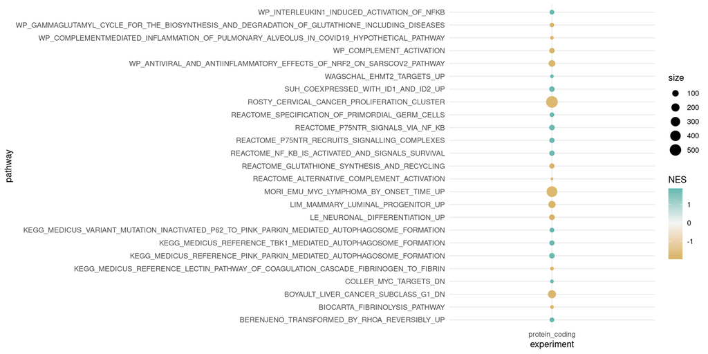

```r
enrichment_df |>
  dplyr::filter((experiment %in% c("protein_coding")) & (abs(NES) > 1.75)) |>
  dplyr::arrange(padj) |>
  dplyr::slice_head(n = 25) |>
  ggplot2::ggplot(ggplot2::aes(pathway, experiment)) +
  ggplot2::geom_point(ggplot2::aes(col = NES, size = size)) +
  ggplot2::coord_flip() +
  ggplot2::theme_minimal() +
  ggplot2::scale_colour_gradient2(low = "#d8b365", mid = "#f5f5f5", high = "#5ab4ac", midpoint = 0)
```

By simply filtering, we can also plot the enrichment for the unproductive transcript types:

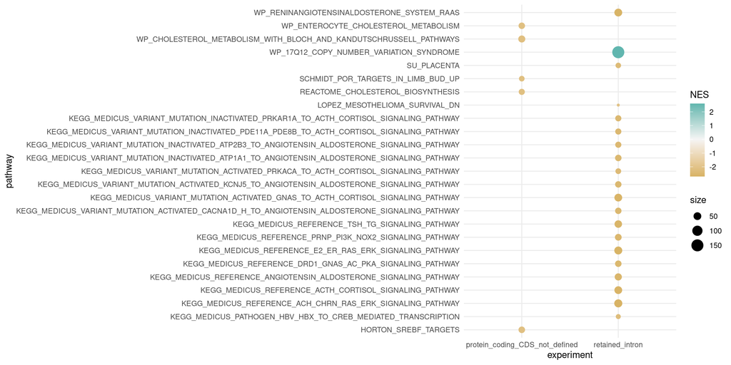

```r
enrichment_df |>
  dplyr::filter((!experiment %in% c("protein_coding", "unproductive")) & abs(NES) > 2) |>
  dplyr::arrange(padj) |>
  dplyr::slice_head(n = 25) |>
  ggplot2::ggplot(ggplot2::aes(pathway, experiment)) +
  ggplot2::geom_point(ggplot2::aes(col = NES, size = size)) +
  ggplot2::coord_flip() +
  ggplot2::theme_minimal() +
  ggplot2::scale_colour_gradient2(low = "#d8b365", mid = "#f5f5f5", high = "#5ab4ac", midpoint = 0)
```

### Genomic Context Plot

Finally, we can use a `.gff` file, that can also be downloaded from GENCODE, to plot the interval of transcripts. This allows us to see differences in exon/intron compositions between different isoforms of a given gene. The `.gff` need to be of the same version as your reference transcriptome.

```r
exon_df <- isoformic::prepare_exon_annotation(
  gene_name = "SCN8A",
  file_path = "ref/gencode.v48.annotation.gff3.gz", # TODO: add path_package() instead of local read_csv?
  file_type = "gff"
  )
```

The plot can be created using the function `plot_tx_context()`. Inspired by the Ensembl genome browser visualization, here exons are represented by the rectangles, and introns by the lines. The transcript type color scheme is also applied.

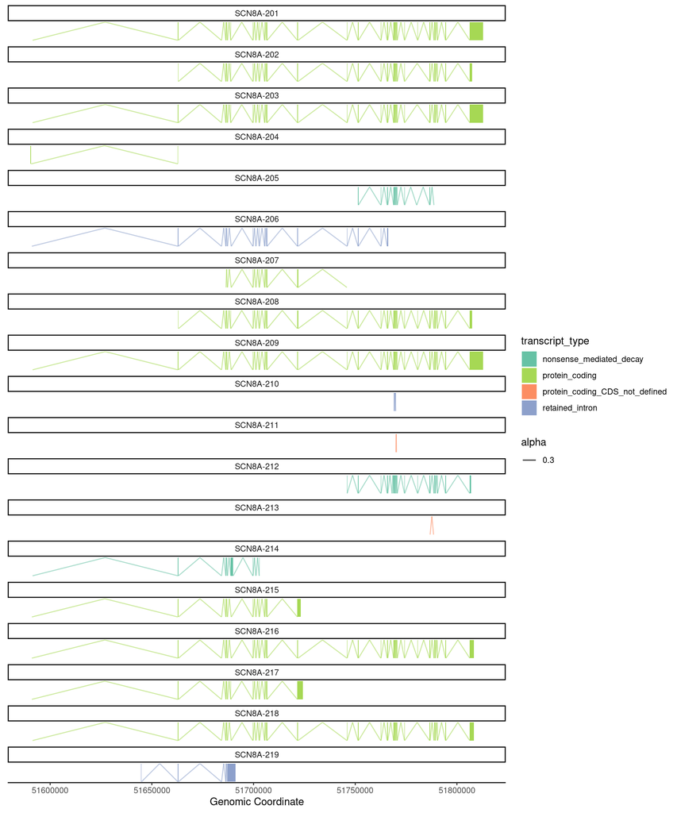

```r
tx_to_gene <- txtogene_hv48

exon_df |>
  isoformic::plot_tx_context()
```

As mentioned before, all of these functions are covered in depth, with additional demonstrations, in the [main vignette](https://luciorq.github.io/isoformic/articles/isoformic_intro.html).

## References

Jousheghani, Z. Z., Singh, N. P., & Patro, R. (2025). Oarfish: enhanced probabilistic modeling leads to improved accuracy in long read transcriptome quantification. Bioinformatics, 41(Supplement_1), i304–i313. https://doi.org/10.1093/bioinformatics/btaf240

Van Goubergen, J., Peřina, M., Handle, F., Morales, E., Kremer, A., Schmidt, O., Kristiansen, G., Cronauer, M. V., & Santer, F. R. (2024). Targeting the CLK2/SRSF9 splicing axis in prostate cancer leads to decreased ARV7 expression. Molecular Oncology. https://doi.org/10.1002/1878-0261.13728